# Il mondo del cinema - Progetto ADS

2025-01-20

[figure not shown]

## Cosa vedremo oggi

- Introduzione
- Analisi esplorativa
- Grafo degli attori
- Grafo delle case produttrici
- Conclusioni

## Introduzione

## Fonte dei dati

Il dataset che andrò ad utilizzare riguarda un insieme di quasi 5000 film catalogati sul portale **TMDB** (The Movie Database).

[figure not shown]

## Motivazioni

Ho scelto questo dataset perché:

- i film coprono un ampio intervallo temporale,
- tutti gli attori, case produttrici e i membri del cast sono identificati univocamente,
- la fonte dei dati è un portale molto affidabile.

## Analisi esplorativa

## Gradimento del pubblico

*“I film considerati migliori dal pubblico sono anche quelli piu popolari tra esso?”*

**Nota**: per popolarità si intende una misura che considera diversi parametri di interazione degli utenti con un film sul portale (ad esempio votazioni, visite della pagina, gradimento, ecc…).

**Nota**: affinchè le medie dei voti risultino significative, ho considerato solo i film che hanno ricevuto almeno 20 voti.

## I “migliori”

| Titolo | Media voti |
| --- | --- |
| The Shawshank Redemption | 8.5 |
| The Godfather | 8.4 |
| Fight Club | 8.3 |
| Schindler’s List | 8.3 |
| Spirited Away | 8.3 |
| The Godfather: Part II | 8.3 |
| Pulp Fiction | 8.3 |
| Whiplash | 8.3 |
| The Dark Knight | 8.2 |
| The Green Mile | 8.2 |

## I più popolari

| Titolo | Popolarità |
| --- | --- |
| Minions | 875.5813 |
| Interstellar | 724.2478 |
| Deadpool | 514.5700 |
| Guardians of the Galaxy | 481.0986 |
| Mad Max: Fury Road | 434.2786 |
| Jurassic World | 418.7086 |
| Pirates of the Caribbean: The Curse of the Black Pearl | 271.9729 |
| Dawn of the Planet of the Apes | 243.7917 |
| The Hunger Games: Mockingjay - Part 1 | 206.2272 |
| Big Hero 6 | 203.7346 |

## Popolarità vs media dei voti

Il primo film che compare in entrambe le classifiche è:

```
## Whiplash
```

prendendo in considerazione 13 film per classifica. Inoltre,

```
## solo il 43.8% dei primi 1000 film
```

si trova in entrmabe le classifiche.

## Popolarità vs media dei voti

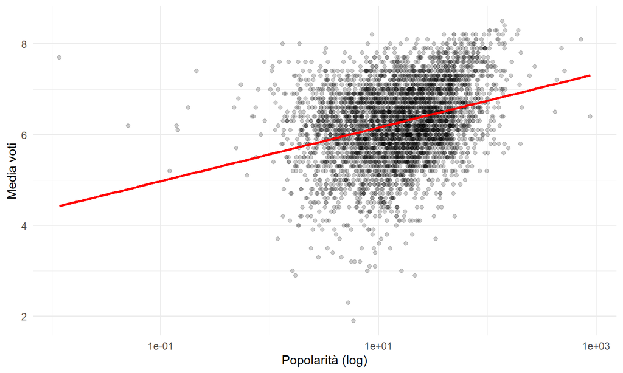

```
## Il coefficiente di correlazione è: 0.278
```

## Durata dei film

*“La durata dei film è cambiata nel tempo?”*

[figure not shown]

## Durata dei film per decennio

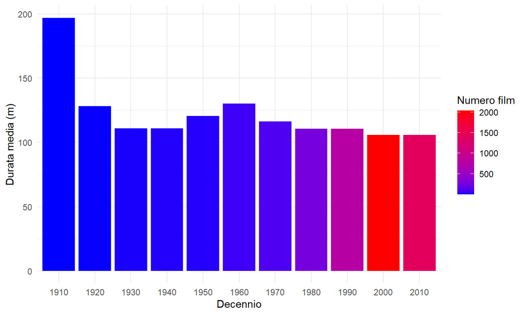

## Differenza di genere

*“Nel mondo del cinema, ci sono differenze tra il numero di uomini e di donne* *che vi lavorano?“*

**Nota**: il dataset conteneva attori senza il genere specificato. Per questa e le successive analisi, non li prenderò in considerazione.

## Genere degli attori nei film

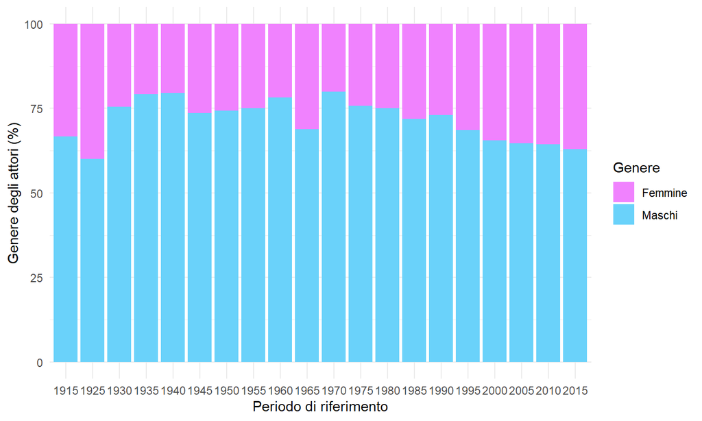

## Genere dei lavoratori nei film

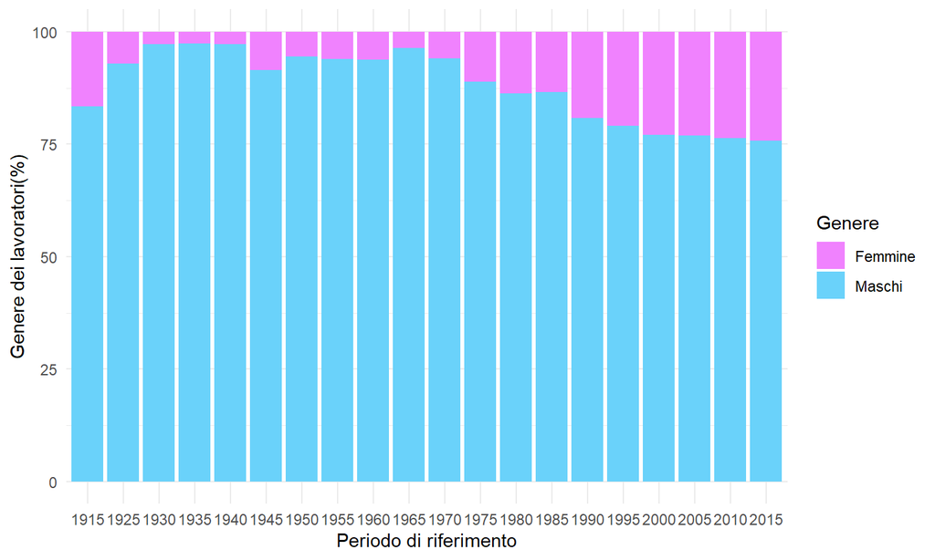

## Regia

*“E per quanto riguarda i registi?”*

[figure not shown]

## Numero di registi per genere

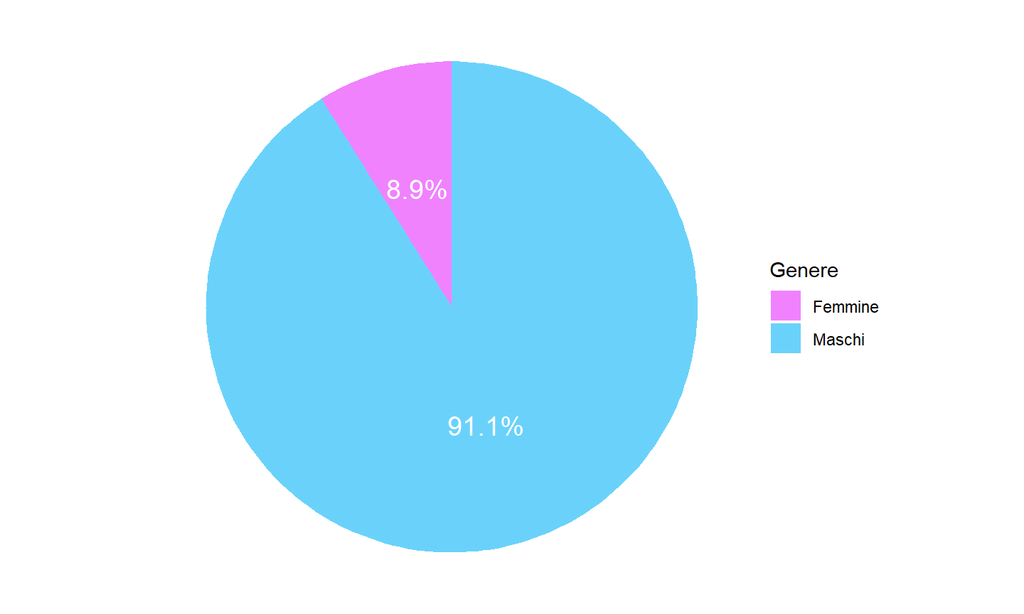

## Numero di film per genere del regista

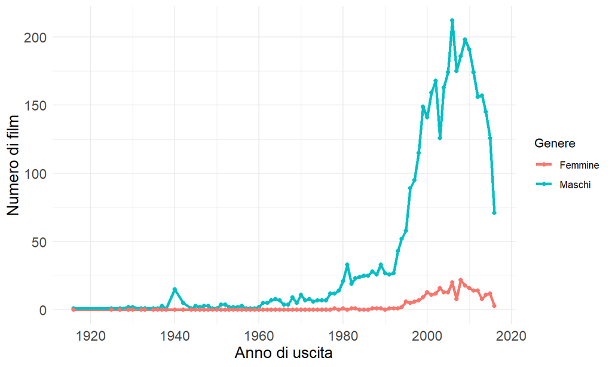

## Il genere del regista influenza gli attori?

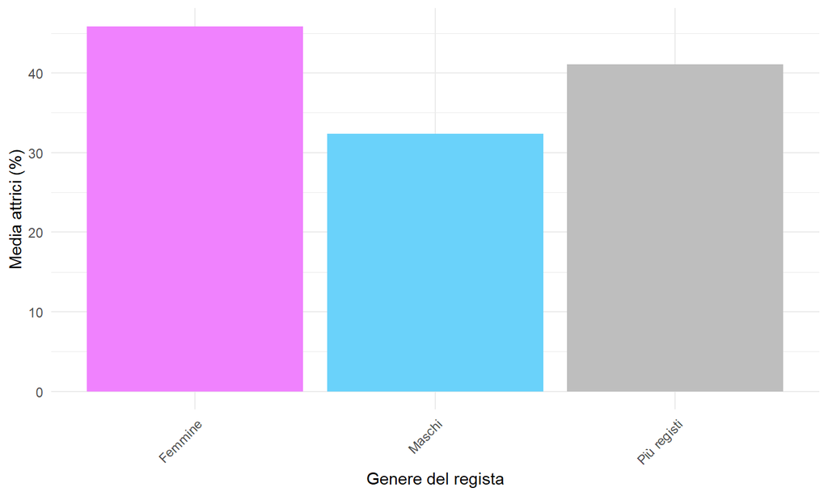

## Grafo degli attori

## Introduzione

Il primo grafo costruito rappresenta le collaborazioni tra diversi attori nel mondo del cinema. Ogni nodo corrisponde a un attore, mentre ogni arco (indiretto) indica che i due attori hanno collaborato in uno o più film. Il peso dell’arco rappresenta il numero di film in cui i due attori hanno lavorato insieme.

**Nota**: per evitare che il grafo diventi troppo grande, sono stati considerati solo i collegamenti tra attori che abbiano lavorato insieme in film successivi al 1990.

## Caratteristiche

```
## Il grafo è formato da 23135 nodi (attori) e da 693568 archi.
```

Non è connesso. Possiamo inoltre notare che:

```
## la componente gigante è formata da 22982 nodi,
## che equivalgono al 99.34 % dei nodi totali.
```

Lavoriamo dunque con la componente gigante.

```
## Il diametro del grafo è pari a 9 nodi.
```

```
## La transitività del grafo è pari a: 0.252.
```

## Distribuzione di grado

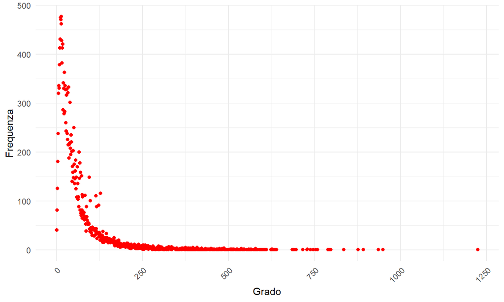

```
## Il grado medio è: 60.335
```

## Distribuzione di grado (log - log)

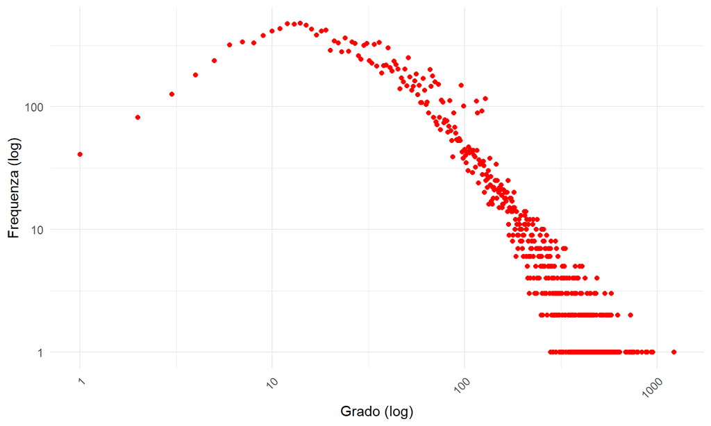

Non si tratta di una power-law.

## Considerazioni

Il grafo è ancora molto grande.

Vediamo cosa succede andando tagliare gli archi che rappresentano poche collazborazioni mantenendo solo i gruppi di attori che hannno lavorato maggiornente assieme.

## Considerazioni

| Peso | Numero nodi | Grado medio | Numero componenti | Dimensioni max componente | Transitività |
| --- | --- | --- | --- | --- | --- |
| 1 | 22982 | 60.335 | 58 | 22982 | 0.252 |
| 2 | 5127 | 7.593 | 222 | 4589 | 0.352 |
| 3 | 1291 | 6.020 | 105 | 1035 | 0.664 |
| 4 | 459 | 4.644 | 50 | 308 | 0.807 |
| 5 | 207 | 3.884 | 41 | 28 | 0.865 |
| 6 | 103 | 4.252 | 25 | 21 | 0.925 |
| 7 | 47 | 1.574 | 15 | 10 | 0.278 |
| 8 | 20 | 1.500 | 7 | 8 | 0.273 |
| 9 | 14 | 1.428 | 5 | 6 | 0.250 |
| 10 | 8 | 1.250 | 3 | 4 | 0.000 |
| 11 | 5 | 1.200 | 2 | 3 | 0.000 |
| 12 | 2 | 1.000 | 1 | 2 | NaN |

## Almeno cinque collaborazioni

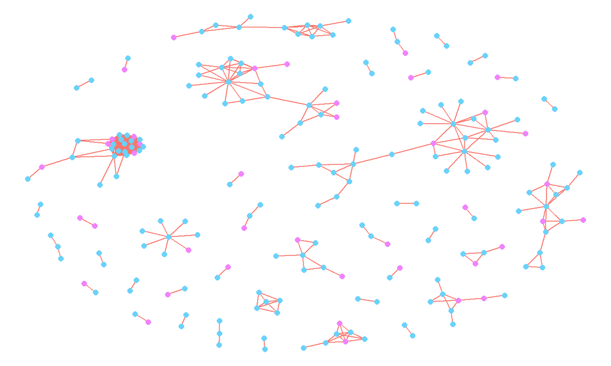

## Almeno sette collaborazioni

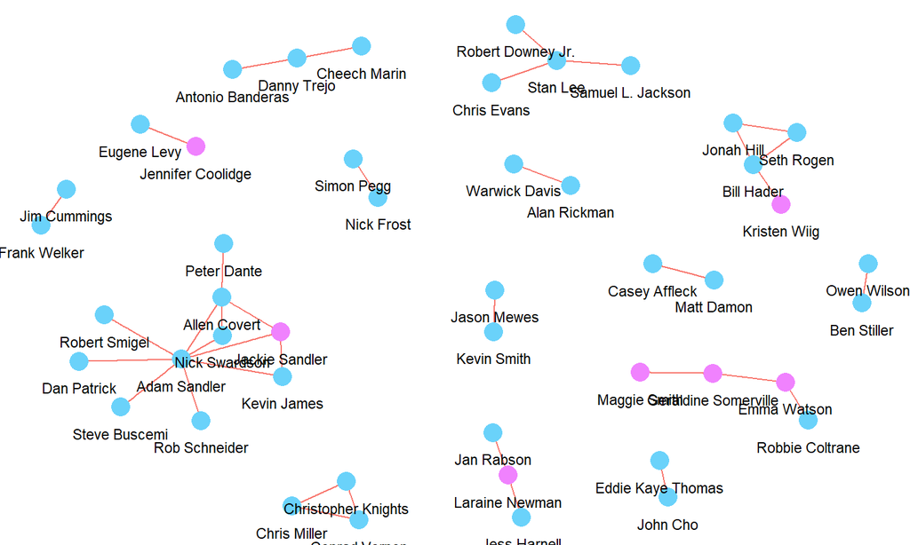

## Attori che hanno fatto più film

| Attore | Apparizioni |
| --- | --- |
| Samuel L. Jackson | 67 |
| Robert De Niro | 57 |
| Bruce Willis | 51 |
| Matt Damon | 48 |
| Morgan Freeman | 46 |
| Steve Buscemi | 43 |
| Liam Neeson | 41 |
| Johnny Depp | 40 |
| Owen Wilson | 40 |
| John Goodman | 39 |

## Incassi dei film

In genere, un film viene considerato un flop quando non recupera il budget investito nella sua produzione. Al contrario, un film viene definito un successo quando incassa almeno una volta e mezza l’importo del budget speso.

## Flop e Top

Alcuni casi eclatanti:

| Titolo | Perdita ($) |
| --- | --- |
| The Lone Ranger | -165710090 |
| The Alamo | -119180039 |
| Mars Needs Moms | -111007242 |

| Titolo | Guadagno ($) |
| --- | --- |
| Avatar | 2550965087 |
| Titanic | 1645034188 |
| Jurassic World | 1363528810 |

## Centralità

*Possiamo utilizzare delle misure di centralità come indice per capire la* *popolarità e il guadagno di un film in base agli attori che vi partcipano?*

Di seguito la tabella delle correlazioni.

| Metodo | Guadagno | Popolarità |
| --- | --- | --- |
| Degree | 0.1135832 | 0.1191682 |
| Closeness | 0.0967994 | 0.1065974 |
| Betweenness | 0.0777412 | 0.0939071 |

## Centralità media vs popolarità

[figure not shown]

## Grafo delle case cinematografiche

## Introduzione

Il secondo grafo rappresenta la relazione tra le case cinematografiche e la loro produzione di film. Ogni arco indica una collaborazione tra due case, e il peso degli archi corrisponde al numero di film prodotti insieme.

**Nota**: Ho deciso di concentrarmi principalmente sulle case cinematografiche più produttive, mantenendo solo quelle che hanno prodotto almeno 10 film e le collaborazioni durature, ossia quelle con almeno 3 film realizzati insieme.

## Caratteristiche

```
## Il grafo è formato da 159 nodi (case produttrici) e da 197 archi.
```

Non è connesso. Possiamo inoltre notare che:

```
## la componente gigante è formata da 102 nodi,
## che equivalgono al 64.15 % dei nodi totali.
```

Lavoriamo dunque con la componente gigante.

```
## Il diametro del grafo è pari a 7 nodi.
```

```
## La transitività del grafo è pari a: 0.201.
```

## La componente gigante

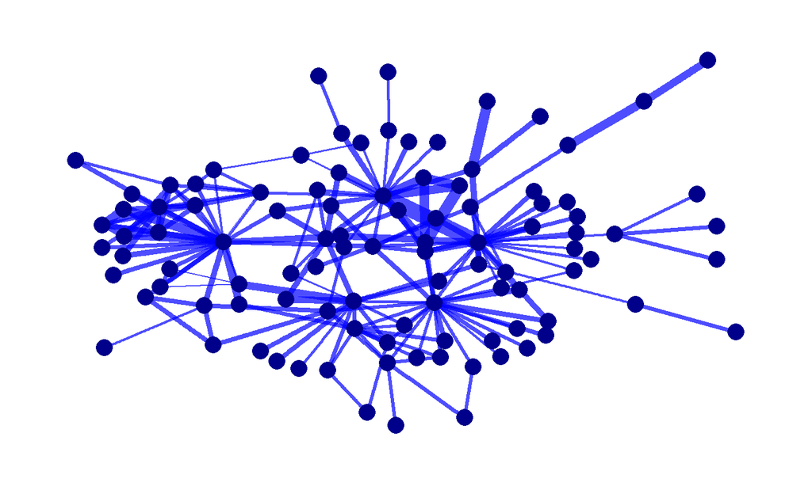

## Distribuzione di grado

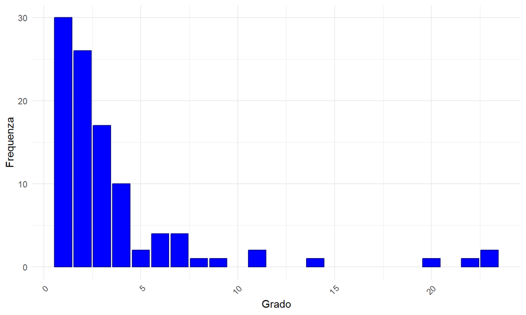

```
## Il grado medio è pari a 3.686.
```

## Divisione in comunità

*Le case di produzione possono essere catalogate in diverse comunità?* *Riusciamo a trovare qualche caratteristica significativa all’interno di esse?*

Osserviamo i risultati di 3 algoritmi.

## Algoritmo Fast Greedy

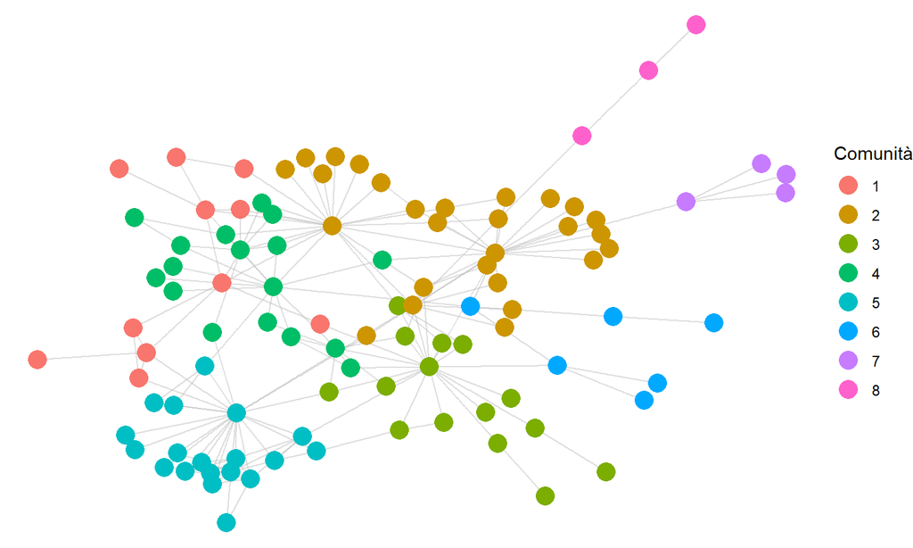

```
## Il valore di modularità applicando fast greedy è 0.591
```

## Algoritmo Edge Betweenness

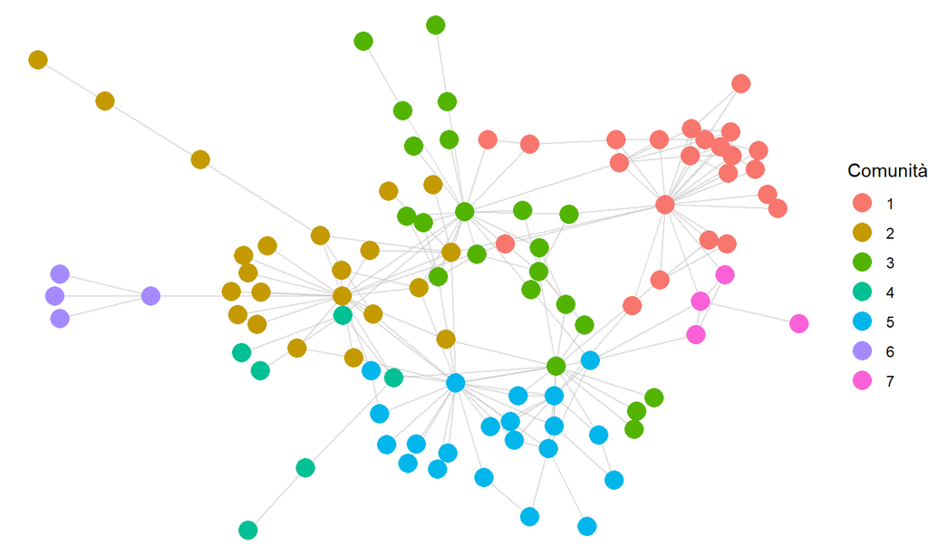

```
## Il valore di modularità applicando edge betweenneess è 0.601
```

## Algoritmo Label Propagation

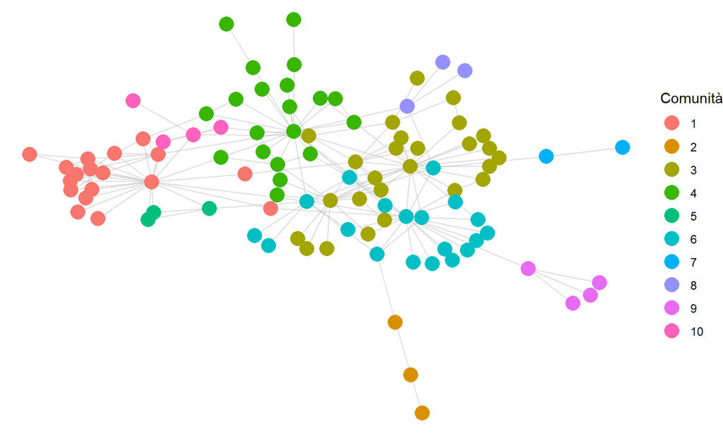

```
## Il valore di modularità applicando label propagation è 0.604
```

## Analisi delle categorie

Di seguito, analizzo le categorie.

## Americano, Inglese, Neozelandese

```
## Eon Productions
## WingNut Films
## New Line Cinema
## Metro-Goldwyn-Mayer (MGM)
## United Artists
## BenderSpink
```

```
## Nella comunità 4 sono presenti 6 nodi.
```

```
## Dalla loro collaborazione sono stati creati 38 film.
```

## Varie società Americane

```
## Imagine Entertainment
## Universal Pictures
## Relativity Media
## Dentsu
## Platinum Dunes
## Original Film
## Columbia Pictures Corporation
## PolyGram Filmed Entertainment
## Media Rights Capital
## Tribeca Productions
```

```
## Nella comunità 5 sono presenti 21 nodi.
```

```
## Dalla loro collaborazione sono stati creati 260 film.
```

## Animazione e colossal

```
## Walt Disney Pictures
## Jerry Bruckheimer Films
## Revolution Sun Studios
## Paramount Pictures
## Amblin Entertainment
```

```
## ...
```

```
## Nella comunità 2 sono presenti 22 nodi.
```

```
## Dalla loro collaborazione sono stati creati 209 film.
```

## Studi europei

```
## Canal+
## EuropaCorp
## TF1 Films Production
## France 2 Cinéma
```

```
## Nella comunità 7 sono presenti 4 nodi.
```

```
## Dalla loro collaborazione sono stati creati 29 film.
```

## Colossi Americani, Marvel

```
## Ingenious Film Partners
## Twentieth Century Fox Film Corporation
## Dune Entertainment
## Marvel Enterprises
## Bad Hat Harry Productions
```

```
## ...
```

```
## Nella comunità 1 sono presenti 23 nodi.
```

```
## Dalla loro collaborazione sono stati creati 415 film.
```

## Colossi Americani, DC

```
## Columbia Pictures
## Legendary Pictures
## Warner Bros.
## DC Entertainment
## DC Comics
```

```
## ...
```

```
## Nella comunità 3 sono presenti 22 nodi.
```

```
## Dalla loro collaborazione sono stati creati 297 film.
```

## Società Americane che collaborano

```
## Lionsgate
## Lakeshore Entertainment
## Screen Gems
## Sidney Kimmel Entertainment
```

```
## Nella comunità 6 sono presenti 4 nodi.
```

```
## Dalla loro collaborazione sono stati creati 15 film.
```

## Rivediamo il grafo

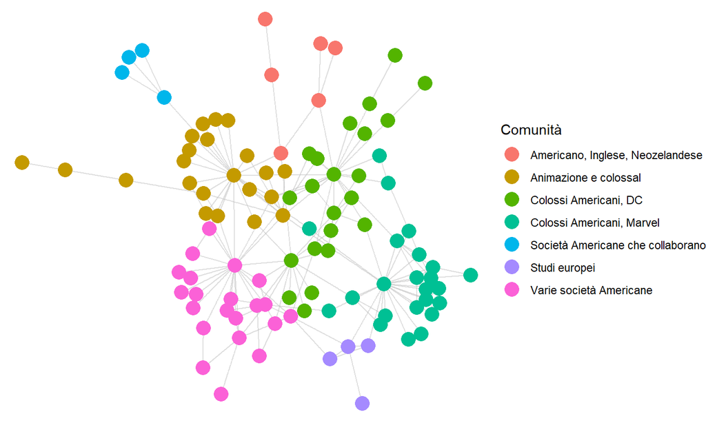

## Conclusioni

## Cosa abbiamo visto

- Analisi esplorativa
- Grafo degli attori
- Grafo delle case produttrici

## Miglioramenti

- sfruttare le API di TMDB per ottenere dati aggiornati,
- calcolare metriche avanzate (modificando i grafi),
- analizzare generi, paesi di produzione e altre informazioni.